# Data Visualization Project 2: Heart Attack and Pneumonia Patient Analysis

**Bryan Amaefule, Kevin Lee, Shannon Lu**

The data we selected for our project shows various information about heart attack and pneumonia patients around the United States. In our project we analyze the frequency and distribution of the payments made by patients with respect to their loaction and disease that they are being treated for.

In order to carry out this analysis in R, you will need to require a few functions

```r
require("tidyr")
require("dplyr")
require("jsonlite")
require("RCurl")
require("reshape2")
require("ggplot2")
```

First, we load the dataset into R and give you an peak at how the dataset is sturctured

```r
hospitals <- data.frame(fromJSON(getURL(URLencode('129.152.144.84:5001/rest/native/?query="select * from hospitalpayments"'),httpheader=c(DB='jdbc:oracle:thin:@129.152.144.84:1521/PDBF15DV.usuniversi01134.oraclecloud.internal', USER='cs329e_ba7433', PASS='orcl_ba7433', MODE='native_mode', MODEL='model', returnDimensions = 'False', returnFor = 'JSON'), verbose = TRUE), ))

tbl_df(hospitals)
```

```
## Source: local data frame [6,426 x 18]
##
##                      HOSPITAL_NAME                       ADDRESS
## 1    D C H REGIONAL MEDICAL CENTER 809 UNIVERSITY BOULEVARD EAST
## 2    D C H REGIONAL MEDICAL CENTER 809 UNIVERSITY BOULEVARD EAST
## 3             HALE COUNTY HOSPITAL              508 GREEN STREET
## 4        ELMORE COMMUNITY HOSPITAL            500 HOSPITAL DRIVE
## 5   D W MCMILLAN MEMORIAL HOSPITAL        1301 BELLEVILLE AVENUE
## 6   D W MCMILLAN MEMORIAL HOSPITAL        1301 BELLEVILLE AVENUE
## 7                  THOMAS HOSPITAL             750 MORPHY AVENUE
## 8                  THOMAS HOSPITAL             750 MORPHY AVENUE
## 9  CITIZENS BAPTIST MEDICAL CENTER              604 STONE AVENUE
## 10 CITIZENS BAPTIST MEDICAL CENTER              604 STONE AVENUE
## ..                             ...                           ...
## Variables not shown: CITY (fctr), STATE (fctr), COUNTY_NAME (fctr),
##   MEASURE_NAME (fctr), MEASURE_ID (fctr), CATEGORY (fctr), DENOMINATOR
##   (fctr), MEASURE_START_DATE (fctr), MEASURE_END_DATE (fctr), LOCATION
##   (fctr), PROVIDER_ID (int), ZIP_CODE (int), PHONE_NUMBER (dbl), PAYMENT
##   (int), LOWER_ESTIMATE (int), HIGHER_ESTIMATE (int)
```

```r
head(hospitals)
```

```
##                    HOSPITAL_NAME                       ADDRESS       CITY
## 1  D C H REGIONAL MEDICAL CENTER 809 UNIVERSITY BOULEVARD EAST TUSCALOOSA
## 2  D C H REGIONAL MEDICAL CENTER 809 UNIVERSITY BOULEVARD EAST TUSCALOOSA
## 3           HALE COUNTY HOSPITAL              508 GREEN STREET GREENSBORO
## 4      ELMORE COMMUNITY HOSPITAL            500 HOSPITAL DRIVE   WETUMPKA
## 5 D W MCMILLAN MEMORIAL HOSPITAL        1301 BELLEVILLE AVENUE    BREWTON
## 6 D W MCMILLAN MEMORIAL HOSPITAL        1301 BELLEVILLE AVENUE    BREWTON
##   STATE COUNTY_NAME                      MEASURE_NAME  MEASURE_ID
## 1    AL  TUSCALOOSA Payment for heart attack patients PAYM_30_AMI
## 2    AL  TUSCALOOSA    Payment for pneumonia patients  PAYM_30_PN
## 3    AL        HALE    Payment for pneumonia patients  PAYM_30_PN
## 4    AL      ELMORE    Payment for pneumonia patients  PAYM_30_PN
## 5    AL    ESCAMBIA Payment for heart attack patients PAYM_30_AMI
## 6    AL    ESCAMBIA    Payment for pneumonia patients  PAYM_30_PN
##                                         CATEGORY DENOMINATOR
```

[output cut: 27 more lines]

The first plot we show is an overview of the hospital payment distribution based on the disease being treated.

```
##
## > hospitals <- data.frame(fromJSON(getURL(URLencode("129.152.144.84:5001/rest/native/?query=\"select * from hospitalpayments\""),
## +     httpheader =  .... [TRUNCATED]
##
## > ggplot() + coord_cartesian() + scale_x_discrete(breaks = NULL) +
## +     scale_y_continuous() + labs(title = "Hospital Payments by Disease") +
## +     .... [TRUNCATED]
```

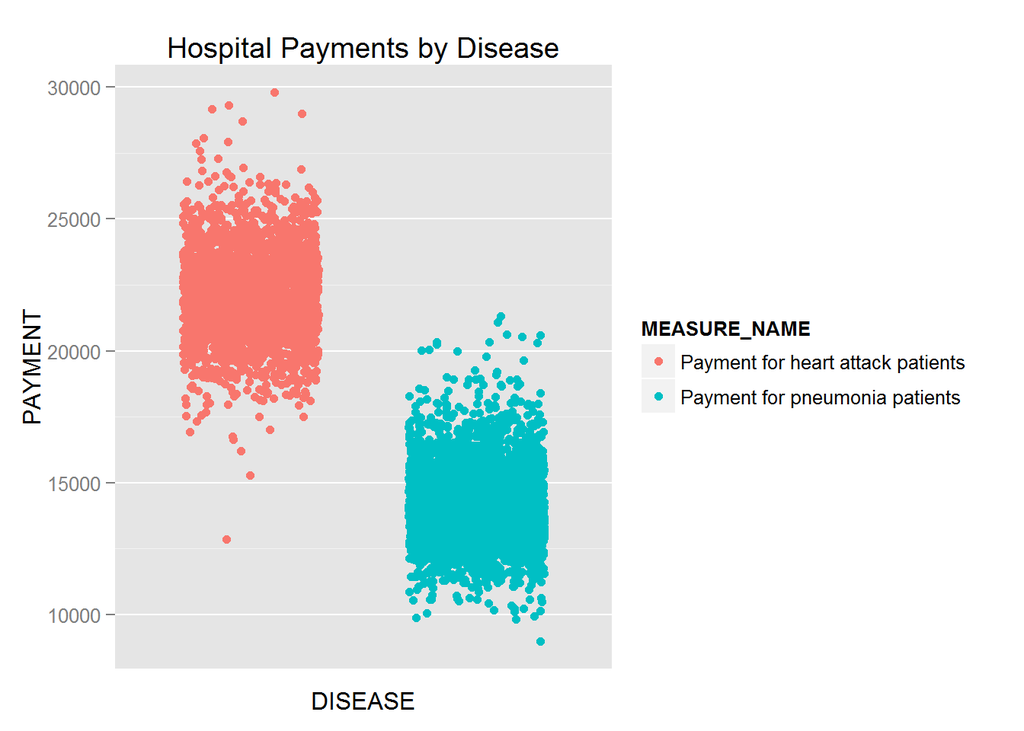

```r
source("../02 Data Wrangling/Plot1.R", echo=TRUE)
```

The plot shows the disparity between the general cost of treatment for heart attack patients and that of pneumonia patients.

A box plot allows us to visualize that disparity with repect to the quartiles of payment

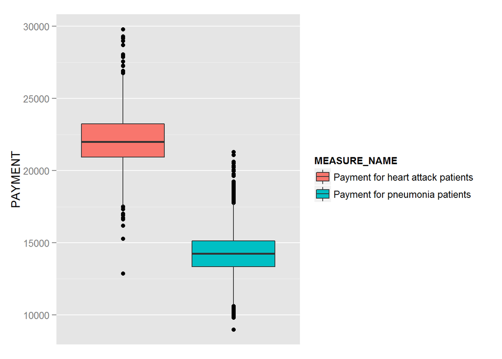

```r
ggplot(hospitals, aes(x=MEASURE_NAME, y=PAYMENT, fill=MEASURE_NAME)) + geom_boxplot() + scale_x_discrete(breaks=NULL) + labs(x=NULL)
```

Using a little data wrangling and the “group_by” and “summarise” function we can see the states with the most patients.

```r
moop <- hospitals %>% group_by(STATE) %>% summarise(n = n()) %>% arrange(desc(n)) %>% tbl_df

head(moop)
```

```
## Source: local data frame [6 x 2]
##
##   STATE   n
## 1    CA 472
## 2    TX 456
## 3    FL 328
## 4    NY 295
## 5    IL 280
## 6    PA 266
```

To get a more “close-to-home” view of things, we use data wrangling to select only the information from patients treated in Texas hospitals. We use the following data wrangling code to select the data we need from only the patients treated in Texas and put into its own data frame, called “Texas”:

```r
Texas <- hospitals %>% select(CITY, STATE, PAYMENT, MEASURE_NAME) %>% filter(STATE == "TX") %>% tbl_df
```

Plotting the new data gives:

```
##
## > ggplot() + coord_cartesian() + scale_x_discrete(breaks = NULL) +
## +     scale_y_continuous() + labs(title = "Hospital Payments by Disease in Texas") .... [TRUNCATED]
```

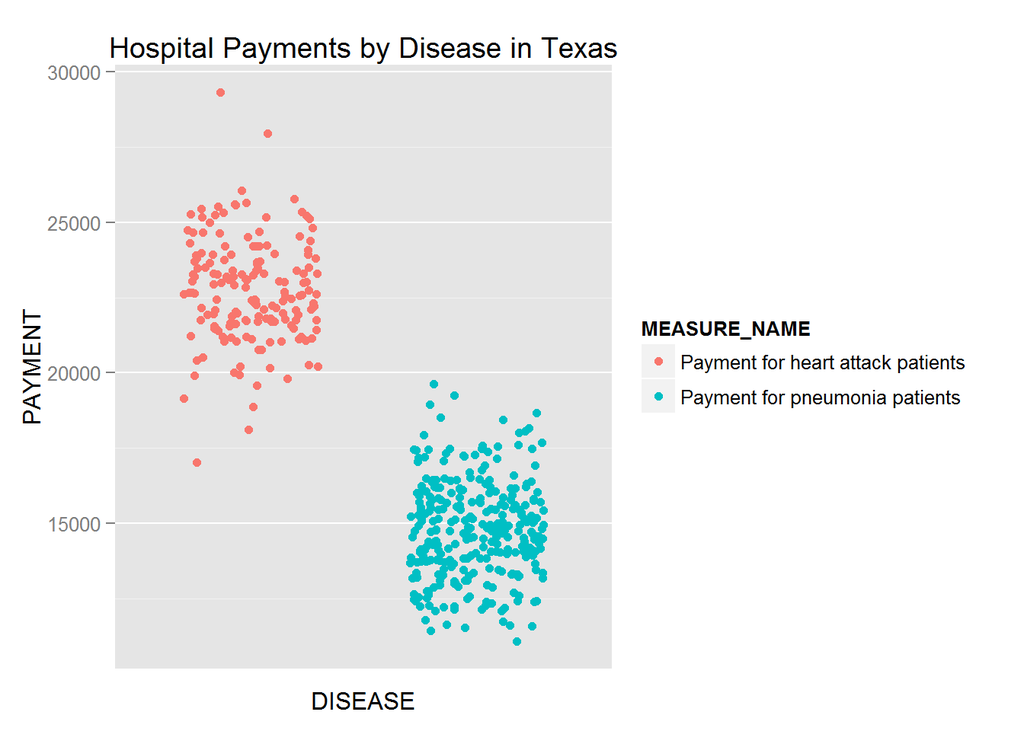

```r
source("../02 Data Wrangling/Plot2.R", echo=TRUE)
```

We can see that not much changes with the distribution of heart attack and pneumonia payments in texas when compared to that of the entire United States.

With a little more data wrangling we can visualize only the heart attack and pneumonia patients from the three biggest cities in Texas: Houston, Dallas, and San Antonio.

```r
HSD <- hospitals %>% select(CITY, STATE, PAYMENT, MEASURE_NAME) %>% filter(STATE == "TX", CITY %in% c("HOUSTON", "SAN ANTONIO", "DALLAS" ))
```

```
##
## > ggplot() + coord_cartesian() + scale_x_discrete(breaks = NULL) +
## +     scale_y_continuous() + facet_wrap(~CITY) + labs(title = "Hospital Payments i ..." ... [TRUNCATED]
```

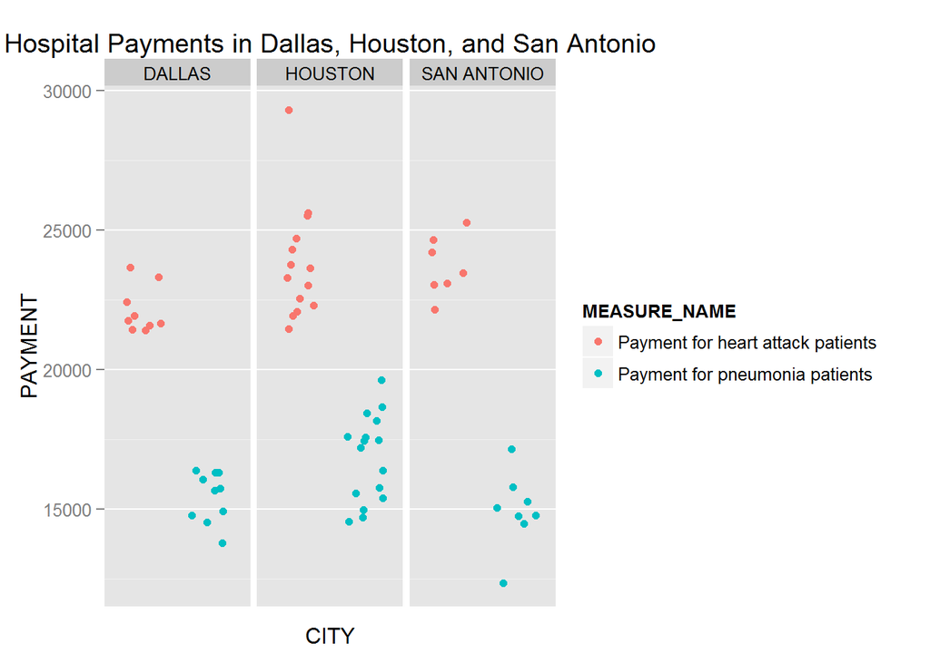

```r
source("../02 Data Wrangling/Plot3.R", echo=TRUE)
```

We see that the highest hospital payment in Texas was from a heart attack patient in Houston who paid nearly $30,000 dollars for treatment.

To get a better under standing of the disparity between hospital payments for pneumonia and those for heart attack we use a density plot with a semi-transparent fill.

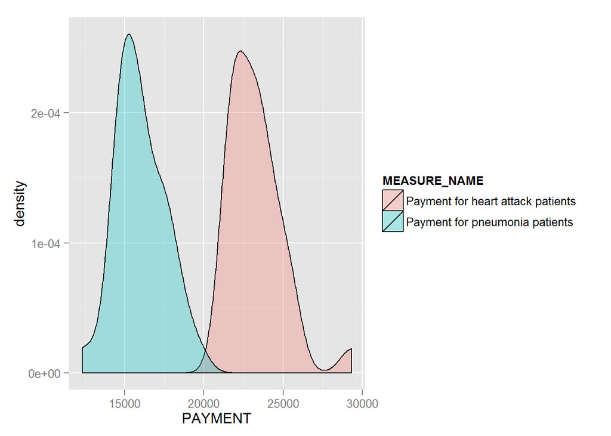

```r
ggplot(HSD, aes(x=PAYMENT, fill=MEASURE_NAME)) + geom_density(alpha=.3)
```

```r
overpaid <- hospitals %>% select(HOSPITAL_NAME, STATE, PAYMENT,LOWER_ESTIMATE, LOCATION, MEASURE_NAME) %>% mutate(Payment_percent = cume_dist(PAYMENT),Overpaid_amt = PAYMENT - LOWER_ESTIMATE) %>% filter(Payment_percent <= 0.1)
```

We plot how much the patient paid against how far over the lower estimate was and we use the disease the patient had in the legend.

```
##
## > ggplot() + coord_cartesian() + scale_x_continuous() +
## +     scale_y_continuous() + labs(title = "Hospital Payments by Disease in Texas") +
## +     l .... [TRUNCATED]
```

[figure not shown]

```r
source("../02 Data Wrangling/Plot5.R", echo=TRUE)
```

Through the various data wrangling sets we were able to visualize the cost of heart attack and pneumonia treatments throughout the United States. Seeing the high costs of healthcare in the US and the rate at which patients overpay is astonishing, especially considering our neighbors in Canada whose health care is delivered through a publicly funded system.